P*PB*S

# PPBS 2018 Pre-Election

The following describes the survey methodology of the 2018 Pre-Election iteration of *The Psychology Political Behavior Studies* (*PPBS*). This report is meant to detail the utilized survey methodology and relevant, general purpose characteristics of both exploratory and confirmatory samples, as well as any extra samples and its combined version. The text is in APA Style and is akin to an APA-like ‘Methods Section’.

PPBS datasets are designed to have an exploratory, quota-based Nationally Representative sample (on Age, Education, Income and Sex), and a Confirmatory (Replication) convenience sample, from the same data source to avoid false positives. Some PPBS studies also have recontacts or extra-samples to answer additional specific research questions (*e.g.*, 2nd Sample in 2016). All data’s coodbooks can be found at the bottom of the page, with a searchable feature allowing to find metadata within and between columns.

For more details, see [PBBS’s Motivation](https://ppbs.science/motivation.html).

Metadata of PBBS 2018 Pre-Election Samples

|  | Sample 1 | Sample 2 | Overall |
| --- | --- | --- | --- |
| Election cycle | Pre-Election 2018 | Pre-Election 2018 | Pre-Election |
| Type | Nationally Representative | Confirmatory (Replication) | Convenience |
| Survey Period (Start) | November 2nd, 2018 | November 2nd, 2018 | November 2nd, 2018 |
| Survey Period (End) | November 6th, 2018 | November 6th, 2018 | November 6th, 2018 |
| Country | United States | United States | United States |
| Attention Checks | Yes (8; various types) | Yes (8; various types) | Yes (8; various types) |
| Time Checks | Yes (8 page submit checks) | Yes (8 page submit checks) | Yes (8 page submit checks) |
| CAPTCHA | Yes (begining of survey) | Yes (begining of survey) | Yes (begining of survey) |
| Sample Size (N) | 1000 | 2728 | 3728 |
| Length of Interview (MD) | 77.59 | 80.44 | 79.02 |
| Attrition (%) | 0.24 | 0.22 | 0.23 |
| Data Quality checks (%) | 0.13 | 0.15 | 0.14 |

**Note.** The Overall column displays the simple, non-weighted on sample size, average between the preceeding columns. If interested in the weighted averages, see section 'Combined Samples' below.

## Nationally Representative Sample (N=1000)

### Sample Description

We hired Cint ([www.cint.com](https://www.cint.com/)), a survey research firm that recruits participants from a pool of over 13 million U.S. citizens, to recruit a nationally representative sample of 1000 Americans (52.8% women) in the months preceding the 2018 US Presidential Election (from November 02 to November 06, 2018)<sup>1</sup>. The quotas were designed to match that of the 2018 US Census’ Current Population Survey (CPS) on age, income, education and gender, with a maximum percentual difference of 5% at the bracket level. The representativeness of the collected sample is presented in the table below, which shows an average absolute deviation of 3.49% points (*MD* = 2.66) from the desired quotas, indicating the sample has achieved a high level of national representativeness.

<sup>1</sup> *Note.* *Only a very small minority of participants started the survey on Election day: 6th November. Two participants, with LOIs of > 4 days, finished the final part of the survey after Election day.*

Representativeness of data

| Demographic | Brackets | Census CPS % | Expected Sample Frequencies | Observed Frequencies | Expected vs. Observed Frequencies | Expected vs. Observed % |
| --- | --- | --- | --- | --- | --- | --- |
| Age | 18 to 24 | 11.78 | 118 | 111 | -7 | -5.93 |
| Age | 25 to 34 | 18.00 | 180 | 172 | -8 | -4.44 |
| Age | 35 to 44 | 16.32 | 163 | 166 | 3 | 1.84 |
| Age | 45 to 54 | 16.67 | 167 | 170 | 3 | 1.80 |
| Age | 55 to 64 | 16.73 | 167 | 174 | 7 | 4.19 |
| Age | 65 to 80+ | 20.50 | 205 | 207 | 2 | 0.98 |
| Education | No high school diploma | 10.90 | 109 | 101 | -8 | -7.34 |
| Education | High school or equivalent | 28.64 | 286 | 291 | 5 | 1.75 |
| Education | Some college, less than 4-yr degree | 28.20 | 282 | 284 | 2 | 0.71 |
| Education | Bachelor's degree or higher | 32.25 | 322 | 324 | 2 | 0.62 |
| Gender | Female | 51.56 | 516 | 528 | 12 | 2.33 |
| Gender | Male | 48.44 | 484 | 472 | -12 | -2.48 |
| Income | Less than $15,000 | 11.01 | 110 | 111 | 1 | 0.91 |
| Income | $15,000 to $24,999 | 9.31 | 93 | 100 | 7 | 7.53 |
| Income | $25,000 to $34,999 | 9.10 | 91 | 95 | 4 | 4.40 |
| Income | $35,000 to $49,999 | 12.66 | 127 | 132 | 5 | 3.94 |
| Income | $50,000 to $74,999 | 17.60 | 176 | 181 | 5 | 2.84 |
| Income | $75,000 to $99,999 | 12.52 | 125 | 123 | -2 | -1.60 |
| Income | $100,000 to $149,999 | 14.60 | 146 | 132 | -14 | -9.59 |
| Income | $150,000 or more | 13.20 | 132 | 126 | -6 | -4.55 |

[figure not shown]

### Regional Representation

As shown below, the distribution of data points per state tracks well with state population. The date has not been designed to be regionally representative, nor it claims to be, but results are not bad (*cf.* [US Decennial Census Tables](https://www.census.gov/programs-surveys/decennial-census/data/tables.2010.html)).

Regional Representation by US State, PPBS 2018 Pre-Election

**Static Map**

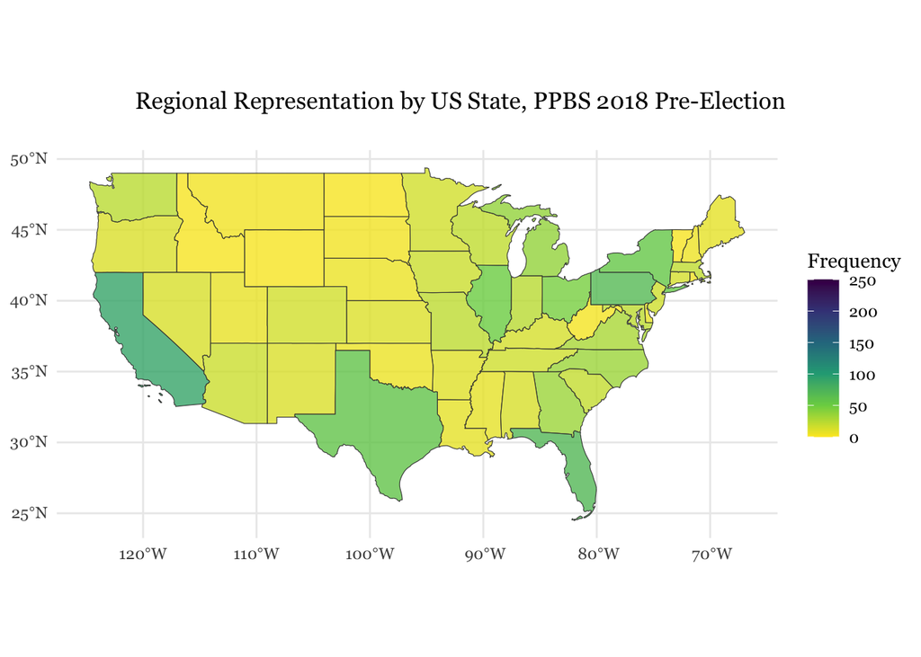

**Interactive Map**

[interactive chart not shown]

[figure not shown]

## Convenience Replication Sample (N=2728)

### Sample Description

The age distribution of our sample was as follows: 18–24 years (0.77%), 25–34 (10.41%), 35–44 (13.86%), 45–54 (15.36%), 55–65 (26.54%), and older than 65 (33.06%). The ethnic breakdown was: White (86%), Black/African American (5.94%), Latino (2.71%), Asian/Pacific Islander (3.15%), Native American (0.66%), Middle Eastern (0.04%), and Other (1.5%). In terms of religion, (22.18% identified as Catholic, 47.58% as Protestant, 3.59% as Jewish,0.33% as Muslim, 13.75% as either Atheist or Agnostic, and 12.57% responded they are not sure or refused to answer. With respect to education, 0% declared their highest educational achievement to be high-school graduation or lower, 17.49% indicated some college and 35.78% indicated having received a Bachelor or Graduate degree. The median income category was $50,000 to $74,999. The exact distribution of Income is as follows: Less $15,000 (0%), $15,000 to $24,999 (12.69%), $25,000 to $34,999 (13.6%), $35,000 to $49,999 (19.81%), $50,000 to $74,999 (23.31%), $75,000 to $99,999 (15.99%), $100,000 to $149,999 (11.65%) and $150,000 more (11.65%). The sample has a larger proportion of women (N= 1936, 70.97%) than men (N= 792, 29.03%).

## Combined Samples (N=3728)

### Sample Description

The age distribution of our sample was as follows: 18–24 years (3.54%), 25–34 (12.23%), 35–44 (14.59%), 45–54 (15.8%), 55–65 (24.09%), and older than 65 (29.75%). The ethnic breakdown was: White (83.91%), Black/African American (7.11%), Latino (3.3%), Asian/Pacific Islander (3.22%), Native American (0.83%), Middle Eastern (0.11%), and Other (1.53%). In terms of religion, (22.96% identified as Catholic, 45.33% as Protestant, 3.43% as Jewish,0.54% as Muslim, 14.57% as either Atheist or Agnostic, and 13.17% responded they are not sure or refused to answer. With respect to education, 2.71% declared their highest educational achievement to be high-school graduation or lower, 20.6% indicated some college and 33.8% indicated having received a Bachelor or Graduate degree. The median income category was $50,000 to $74,999. The exact distribution of Income is as follows: Less $15,000 (0%), $15,000 to $24,999 (12.31%), $25,000 to $34,999 (12.84%), $35,000 to $49,999 (18.51%), $50,000 to $74,999 (22.54%), $75,000 to $99,999 (15.43%), $100,000 to $149,999 (12.49%) and $150,000 more (12.49%).

## Note on Survey Company

Cint has the world’s largest network of integrated panels (4,500+). It was the original creator of a technological system allowing for an exchange of research panels, counting with a pool of participants in the USA of 13,260,833, and worldwide of 100,000,000+ in over 150 countries. Cint provides an [updated, real-time age and gender breakouts by country](https://www.cint.com/consumer-insights-exchange) of its participants’ pool, and is a partner and provider of samples for known giants in the research panels industry like GfK, Lucid, Ipsos, Qualtrics, Kantar, Nielsen, and GMO. Methodologically, Cint applies a variety of industry-standard 3rd party solutions – including Imperium, MaxMind, Firehol, Apility, Google reCAPTCHA and SmartyStreets – and its [ISO-20252 compliant proprietary Fraud Detection tool](https://www.cint.com/quality) – to ensure data quality. Cint also complies with the codes and guidelines of ESOMAR, CASRO, MRA and applicable national market research associations, as well as all applicable data protection laws/regulations - including EU’s strict GDPR. *Most importantly*, and contrary to several traditional companies such as YouGov, Cint not only doesn’t require hosting the questionnaire (leaving researchers in control of data quality checking) but welcomes and recommends the deployment of stringent data validation checks, including but not limited to: analysis of questionnaire completion time, data outliers, unanswered questions, patterned responses, straight-lining traps, and red herring questions.

## Codebook

*Search box on the right finds items in all columns. Search boxes at the column level finds matches in their specific column.*

| Measure/Construct | Variable Code | Item text | Possible values | Sources |
| --- | --- | --- | --- | --- |
| Age | Scr_Age | What is your age? | 1: 18-24 years 2: 25-34 years 3: 35-44 years 4: 45-54 years 5: 55-64 years 6: 65+ | US Census Bureau. Current Population Survey (CPS). Retrieved from https://www.census.gov/programs-surveys/acs US Census Bureau. American community survey (ACS). Retrieved from https://www.census.gov/p… |
| Education | Scr_Edu | What is your education level? | 1: Less than high school 2: High school graduate (includes equivalency) 3: Some college, no degree 4: Bachelor's degree or higher | US Census Bureau. Current Population Survey (CPS). Retrieved from https://www.census.gov/programs-surveys/acs US Census Bureau. American community survey (ACS). Retrieved from https://www.census.gov/p… |
| Income | Scr_Inc | Thinking back over the last year, what was your family’s annual income? | 1: Less than $15.000 2: $15.000 to $24.999 3: $25.000 to $34.999 4: $35.000 to $49.999 5: $50.000 to $74.999 6: $75.000 to $99.999 7: $100.000 to $149.999 8: $150.000 or more | US Census Bureau. Current Population Survey (CPS). Retrieved from https://www.census.gov/programs-surveys/acs US Census Bureau. American community survey (ACS). Retrieved from https://www.census.gov/p… |
| Sex / Gender | Scr_Sex | What is your sex at birth? | 1: Female 2: Male | US Census Bureau. Current Population Survey (CPS). Retrieved from https://www.census.gov/programs-surveys/acs US Census Bureau. American community survey (ACS). Retrieved from https://www.census.gov/p… |
| Political party | Scr_PID | In terms of mainstream political parties, which do you feel closest to – or that best represents your views on political issues? | 1: Democrat 2: Republican | US Census Bureau. Current Population Survey (CPS). Retrieved from https://www.census.gov/programs-surveys/acs US Census Bureau. American community survey (ACS). Retrieved from https://www.census.gov/p… |
| Ideology | Scr_Ideo | In terms of mainstream political ideologies, which do you feel closest to – or that best represents your views on political issues? | 1: The Left and/or Progressivism 2: The Right and/or Conservatism | US Census Bureau. Current Population Survey (CPS). Retrieved from https://www.census.gov/programs-surveys/acs US Census Bureau. American community survey (ACS). Retrieved from https://www.census.gov/p… |
| Voting Behavior | PS_Reg | Are you a registered voter? | 1: Yes 2: No | Original Item |
| Ethnicity | Dem_Eth | What racial or ethnic group describes you? | 1: White 2: Black/African American 3: Hispanic/Latino 4: Asian/Pacific Islander 5: Native American 6: Middle Eastern 7: Other | Smith, Tom W., Davern, Michael, Freese, Jeremy, and Stephen L. Morgan. General Social Surveys, 1972-2018: Cumulative Codebook / Principal Investigator, Tom W. Smith; Co-Principal Investigators, Michae… |
| Religious affiliation, Religiosity | Dem_Rel | What is your religious affiliation/denomination? | 1: Roman Catholic (Catholic) 2:Protestant (Baptist, Methodist, Nondenominational, Lutheran, Presbyterian, Pentecostal, Episcopalian, Reformed, Church of Christ, Jehovah’s Witness) 3: Jewish (Judaism) … | Smith, Tom W., Davern, Michael, Freese, Jeremy, and Stephen L. Morgan. General Social Surveys, 1972-2018: Cumulative Codebook / Principal Investigator, Tom W. Smith; Co-Principal Investigators, Michae… |
| Religious affiliation, Religiosity | Dem_Rel_BA | Would you call yourself a born-again Christian? | 1: Yes 2: No | Smith, Tom W., Davern, Michael, Freese, Jeremy, and Stephen L. Morgan. General Social Surveys, 1972-2018: Cumulative Codebook / Principal Investigator, Tom W. Smith; Co-Principal Investigators, Michae… |

[output cut: 634 more lines]